# Лабораторная работа № 4

Модель «хищник–жертва»

Анна Светцова

1132230807@pfur.ru

Российский университет дружбы народов

2026-10-08

# Информация

## Докладчик

**Анна Светцова**

Российский университет дружбы народов

1132230807@pfur.ru

# Вводная часть

## Актуальность

- Модель Лотки–Вольтерры описывает взаимодействие двух популяций
- Численности хищников и жертв взаимно влияют друг на друга
- Система демонстрирует периодические колебания
- Фазовый портрет позволяет наглядно исследовать динамику системы

## Цель работы

Исследовать модель «хищник–жертва» для варианта 58:

- построить временные зависимости популяций;
- построить фазовый портрет;
- найти стационарное состояние;
- провести параметрическое исследование.

# Постановка задачи

## Исходные данные

Для варианта 58:

$$x(0)=6,\qquad y(0)=23.$$

Здесь:

- $x(t)$ — численность хищников;
- $y(t)$ — численность жертв.

## Модель Лотки–Вольтерры

$$\frac{dx}{dt}=-0.38x+0.043xy,$$

$$\frac{dy}{dt}=0.36y-0.052xy.$$

Взаимодействие двух популяций описывается нелинейными членами $xy$.

# Стационарное состояние

## Условие равновесия

Для ненулевого стационарного состояния обе производные равны нулю:

$$x^*=\frac{0.36}{0.052},
\qquad
y^*=\frac{0.38}{0.043}.$$

Отсюда

$$x^*\approx6.923,
\qquad
y^*\approx8.837.$$

# Основной эксперимент

## Динамика популяций

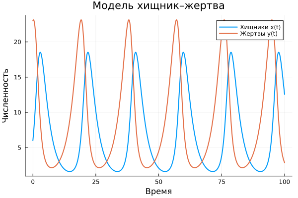

Численности хищников и жертв изменяются периодически и со сдвигом относительно друг друга.

## Фазовый портрет

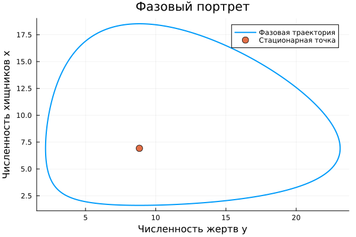

Фазовая траектория образует замкнутый цикл вокруг стационарной точки.

## Хищники

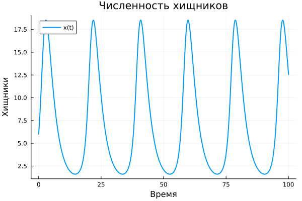

Численность хищников растёт вслед за увеличением доступной численности жертв.

## Жертвы

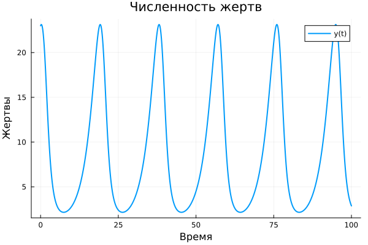

Рост числа хищников приводит к последующему снижению численности жертв.

# Параметрическое исследование

## Изменяемый параметр

Исследуется коэффициент естественной смертности хищников $a$:

$$a\in\{0.30,\;0.38,\;0.46\}.$$

Остальные параметры и начальные условия не изменяются.

## Изменение равновесия

Для выбранного параметра:

$$x^*=\frac{c}{d}$$

остаётся неизменным, а

$$y^*=\frac{a}{b}$$

изменяется вместе с коэффициентом смертности хищников.

## Результат параметрического эксперимента

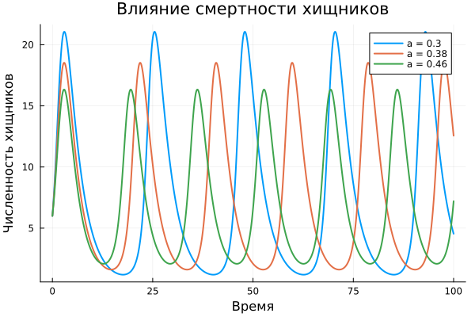

Изменение коэффициента смертности хищников меняет амплитуду колебаний и положение равновесной численности жертв.

# Воспроизводимость

## Организация вычислений

- модель реализована на Julia;
- использован пакет DifferentialEquations;
- исходники оформлены в литературном стиле;
- сформированы Julia-скрипты;
- созданы и выполнены Jupyter Notebook;
- создана документация Quarto;
- результаты сохранены в CSV и PNG.

# Результаты

## Основные результаты

- реализована модель Лотки–Вольтерры для варианта 58;
- построены временные зависимости хищников и жертв;
- построен фазовый портрет;
- найдено стационарное состояние;
- выполнено параметрическое исследование смертности хищников;
- подтверждена воспроизводимость вычислений.

# Итоги

## Вывод

Для заданных начальных условий модель демонстрирует периодические колебания численности хищников и жертв.

Фазовая траектория замкнута вокруг стационарной точки

$$(x^*,y^*)\approx(6.923,\;8.837).$$

Изменение коэффициента смертности хищников влияет на амплитуду колебаний и равновесную численность жертв.